# Task1

Author

Sofia

Published

October 1, 2024

# 1.1Atomic Types

Question description

Create the following variables related to your chosen object: - 4 numeric values (e.g., population, temperature, size, rating)  
- 3 integer values (e.g., number of moons, buildings, inhabitants)  
- 2 logical values (e.g., has_water, is_inhabited)  
- 3 character values (e.g., name, region, category)

```r
# code for solving task
#integer
population <- 39800
area <- 98  # square kilometers
districts <- 4

#charakter
city_name <- "Zvolen"
city_old_name <- "Zolna"
region <- "Banska Bystrica Region"

#numeric
average_temperature <- 10.1       # °C
city_budget_million <- 142.3      # million euros
annual_rainfall_mm <- 720.5       # mm per year
green_area_percent <- 36.8        # % of city covered by greenery

#logical
has_hospital <- TRUE
is_capital <- FALSE
```

# 1.2Vectors

Create three different vectors:

1. **Numeric vector** combining all your numeric and integer variables.  
   *(Use `c()`.)*
2. **Sequence vector** from any number between 10–50 to 100, Choose step between 2 and 10.  
   *(Use `seq()` or `:`.)*
3. **Logical vector** of length 10 with random `TRUE`/`FALSE` values using `sample()`.

```r
#_code for solving task
# 1. Numeric vector
numeric_vector <- c(population, area, districts, average_temperature,
                    city_budget_million, annual_rainfall_mm, green_area_percent)
numeric_vector
```

```
[1] 39800.0    98.0     4.0    10.1   142.3   720.5    36.8
```

```r
# 2. Sequence vector
sequence_vector <- seq(5, 100, by = 20)
sequence_vector
```

```
[1]  5 25 45 65 85
```

```r
# 3. Logical vector
logical_vec <- sample(c(TRUE, FALSE), size = 10, replace = TRUE)
logical_vec
```

```
 [1]  TRUE FALSE  TRUE  TRUE  TRUE  TRUE FALSE FALSE FALSE  TRUE
```

### 1.3 MATRIX

Create a **3×3 matrix** with random numbers between **-50 and 50**  
(using `sample()` or `runif()`), and name its **rows and columns** according to your theme.

```r
#_code for solving task
set.seed(2024)
my_matrix <- matrix(sample(-50:50, 9, replace = TRUE), nrow = 3, ncol = 3)
rownames(my_matrix) <- c("Center", "East", "West")
colnames(my_matrix) <- c("Economy", "Education", "Tourism")
my_matrix
```

```
       Economy Education Tourism
Center      15         9      47
East       -14       -34     -22
West        -6       -19     -40
```

```r
rowMeans(my_matrix)
```

```
   Center      East      West
 23.66667 -23.33333 -21.66667
```

```r
colMeans(my_matrix)
```

```
   Economy  Education    Tourism
 -1.666667 -14.666667  -5.000000
```

# 1.4 LIST

Create a **list** that combines all your previous objects:  
atomic variables, vectors, and matrix. Add one extra element — a short **description** of your universe as a string.

```r
#_code for solving task
zvolen_list <- list(
  city_name = city_name,
  region = region,
  population = population,
  numeric_vector = numeric_vector,
  sequence_vector = sequence_vector,
  logical_vec = logical_vec,
  matrix = my_matrix,
  description = "This is the data universe of Zvolen a historic Slovak city full of green spaces, education, and culture."
)
zvolen_list
```

```
$city_name
[1] "Zvolen"

$region
[1] "Banska Bystrica Region"

$population
[1] 39800

$numeric_vector
[1] 39800.0    98.0     4.0    10.1   142.3   720.5    36.8

$sequence_vector
[1]  5 25 45 65 85

$logical_vec
 [1]  TRUE FALSE  TRUE  TRUE  TRUE  TRUE FALSE FALSE FALSE  TRUE

$matrix
       Economy Education Tourism
Center      15         9      47
East       -14       -34     -22
West        -6       -19     -40

$description
[1] "This is the data universe of Zvolen a historic Slovak city full of green spaces, education, and culture."
```

# 1.5 Factor

Create a **factor variable** representing categories within your universe, e.g.:

- `"low"`, `"medium"`, `"high"`
- `"infant"`, `"child"`, `"adult"`
- `"poor"`, `"average"`, `"rich"`

Make sure you have **at least 5 observations** total.  
Then use `table()` to show how many objects fall into each category.

```r
#code_for solving task
development_stage <- factor(c("low", "medium", "high", "medium", "high", "low", "medium"))
table(development_stage)
```

```
development_stage
  high    low medium
     2      2      3
```

# 1.6 Data Frame

Create a **data frame** related to your object that includes:

```r
#_code for solving task
zvolen_df <- data.frame(
  District = c("Center", "East", "West", "North", "South"),
  Population = c(12000, 9500, 7800, 5500, 7000),
  Has_Schools = c(TRUE, TRUE, TRUE, FALSE, TRUE),
  Area_km2 = c(10.2, 15.3, 8.7, 12.5, 11.0),
  Category = factor(c("urban", "residential", "residential", "suburban", "mixed"))
)

colnames(zvolen_df) <- c("District_Name", "Population_Size", "Has_Schools", "Area_km2", "Category")

str(zvolen_df)
```

```
'data.frame':   5 obs. of  5 variables:
 $ District_Name  : chr  "Center" "East" "West" "North" ...
 $ Population_Size: num  12000 9500 7800 5500 7000
 $ Has_Schools    : logi  TRUE TRUE TRUE FALSE TRUE
 $ Area_km2       : num  10.2 15.3 8.7 12.5 11
 $ Category       : Factor w/ 4 levels "mixed","residential",..: 4 2 2 3 1
```

```r
summary(zvolen_df)
```

```
 District_Name      Population_Size Has_Schools        Area_km2
 Length:5           Min.   : 5500   Mode :logical   Min.   : 8.70
 Class :character   1st Qu.: 7000   FALSE:1         1st Qu.:10.20
 Mode  :character   Median : 7800   TRUE :4         Median :11.00
                    Mean   : 8360                   Mean   :11.54
                    3rd Qu.: 9500                   3rd Qu.:12.50
                    Max.   :12000                   Max.   :15.30
        Category
 mixed      :1
 residential:2
 suburban   :1
 urban      :1
```

```r
zvolen_df$Density <- zvolen_df$Population_Size / zvolen_df$Area_km2
zvolen_df
```

```
  District_Name Population_Size Has_Schools Area_km2    Category   Density
1        Center           12000        TRUE     10.2       urban 1176.4706
2          East            9500        TRUE     15.3 residential  620.9150
3          West            7800        TRUE      8.7 residential  896.5517
4         North            5500       FALSE     12.5    suburban  440.0000
5         South            7000        TRUE     11.0       mixed  636.3636
```

## Task 2: Subsetting & Missing Data in Your Mini-Universe

### 2.1. Querying Vectors

Let’s start with the vectors you created in **Task 1**.

2.1.1. From your **Sequence vector** (the one with all your numbers):

- Select and print the 3rd element.
- Select and print elements 2 through 5.
- Select and print all values that are greater than 20 (or another number that makes sense for your data).

```r
# Select and print the 3rd element
sequence_vector[3]
```

```
[1] 45
```

```r
# Select and print elements 2 through 5
sequence_vector[2:5]
```

```
[1] 25 45 65 85
```

```r
# Select and print all values greater than 20
sequence_vector[sequence_vector > 20]
```

```
[1] 25 45 65 85
```

2.1.2. From your **Logical vector**:

- Select and print only the TRUE values. (Hint: `your_vector[your_vector]`).
- Use `which()` to get the indices (positions) of all the `TRUE` values.

```r
# Select and print only the TRUE values
logical_vec[logical_vec]
```

```
[1] TRUE TRUE TRUE TRUE TRUE TRUE
```

```r
# Get indices (positions) of all TRUE values
which(logical_vec)
```

```
[1]  1  3  4  5  6 10
```

### 2.2. Querying Your “Universe” List

Use your main list from **Task 1**.

- Access and print the **description** string using the `$` operator
- Access and print your **3x3 matrix** using double brackets `[[ ]]`.
- Access and print the **second element** from your **vector element** within the list. (This will be a “list-within-a-list” access).

```r
# Access and print the description string using $
zvolen_list$description
```

```
[1] "This is the data universe of Zvolen a historic Slovak city full of green spaces, education, and culture."
```

```r
# Access and print your 3x3 matrix using double brackets [[ ]]
zvolen_list[[7]]   # or zvolen_list$matrix
```

```
       Economy Education Tourism
Center      15         9      47
East       -14       -34     -22
West        -6       -19     -40
```

```r
# Access and print the 2nd element from your numeric vector inside the list
zvolen_list$numeric_vector[2]
```

```
[1] 98
```

### 2.3. Investigating Your Data Frame

Use the **data frame** you created in **Task 1**.

- Print the **first 3 rows**. (Use `head()`.)
- Print the value from the **4th row, 1st column**.
- Print only the column that contains your logical values (e.g., `is_habitable`) as a vector.

**Logical Subsetting**: Create a new data frame `df_subset` that contains only the rows that meet a specific logical condition.

```r
# Print the first 3 rows
head(zvolen_df, 3)
```

```
  District_Name Population_Size Has_Schools Area_km2    Category   Density
1        Center           12000        TRUE     10.2       urban 1176.4706
2          East            9500        TRUE     15.3 residential  620.9150
3          West            7800        TRUE      8.7 residential  896.5517
```

```r
# Print the value from the 4th row, 1st column
zvolen_df[4, 1]
```

```
[1] "North"
```

```r
# Print only the logical column (Has_Schools)
zvolen_df$Has_Schools
```

```
[1]  TRUE  TRUE  TRUE FALSE  TRUE
```

```r
# Logical Subsetting: keep only districts with population > 8000
zvolen_subset <- zvolen_df[zvolen_df$Population_Size > 8000, ]
zvolen_subset
```

```
  District_Name Population_Size Has_Schools Area_km2    Category  Density
1        Center           12000        TRUE     10.2       urban 1176.471
2          East            9500        TRUE     15.3 residential  620.915
```

```r
# %in% Subsetting: select districts with "urban" or "residential" category
zvolen_subset_2 <- zvolen_df[zvolen_df$Category %in% c("urban", "residential"), ]
zvolen_subset_2
```

```
  District_Name Population_Size Has_Schools Area_km2    Category   Density
1        Center           12000        TRUE     10.2       urban 1176.4706
2          East            9500        TRUE     15.3 residential  620.9150
3          West            7800        TRUE      8.7 residential  896.5517
```

### 2.4. Handling “Corrupted” Data (`NA`)

Create a copy of your original data frame (e.g., `df_corrupted <- your_df`).

**Introduce 3 `NA`s** into your df_corrupted at specific locations.

- Example: `df_corrupted[2, 3] <- NA`

**Find `NAs`**:

- Use `sum(is.na(df_corrupted)`) to find the **total number** of missing values.
- Use `colSums(is.na(df_corrupted))` to see how many `NA`s are in **each column**.

**Calculate with `NA`s**:

- Calculate the `mean()` of the numeric column where you added an `NA`.

**Filter `NA`s**:

- Use `na.omit(df_corrupted)` to create a new, “clean” data frame that contains only the complete rows.

```r
# Create a copy of your original data frame
zvolen_corrupted <- zvolen_df

# Introduce 3 NA values in specific locations
zvolen_corrupted[2, 2] <- NA     # Population_Size for East
zvolen_corrupted[4, 3] <- NA     # Has_Schools for North
zvolen_corrupted[5, 5] <- NA     # Category for South

# Find total number of missing values
sum(is.na(zvolen_corrupted))
```

```
[1] 3
```

```r
# Find how many NAs per column
colSums(is.na(zvolen_corrupted))
```

```
  District_Name Population_Size     Has_Schools        Area_km2        Category
              0               1               1               0               1
        Density
              0
```

```r
# Calculate mean of Population_Size (with NAs)
mean(zvolen_corrupted$Population_Size)
```

```
[1] NA
```

```r
# Calculate mean ignoring NAs
mean(zvolen_corrupted$Population_Size, na.rm = TRUE)
```

```
[1] 8075
```

```r
# Remove rows with NAs
zvolen_clean <- na.omit(zvolen_corrupted)
zvolen_clean
```

```
  District_Name Population_Size Has_Schools Area_km2    Category   Density
1        Center           12000        TRUE     10.2       urban 1176.4706
3          West            7800        TRUE      8.7 residential  896.5517
```

### 2.5. Bonus Challenge: `which()`

Use `which.max()` or `which.min()` to find the **row number** (index) of the observation with the highest or lowest value in one of your numeric columns.

Use that index to print the row with that observation.

- Example: `highest_pop_index <- which.max(your_df$population)`
- Example: `your_df[highest_pop_index, ]`

```r
# Find the district with the highest population
highest_pop_index <- which.max(zvolen_df$Population_Size)
zvolen_df[highest_pop_index, ]
```

```
  District_Name Population_Size Has_Schools Area_km2 Category  Density
1        Center           12000        TRUE     10.2    urban 1176.471
```

```r
# Find the district with the lowest population
lowest_pop_index <- which.min(zvolen_df$Population_Size)
zvolen_df[lowest_pop_index, ]
```

```
  District_Name Population_Size Has_Schools Area_km2 Category Density
4         North            5500       FALSE     12.5 suburban     440
```

## Task 3: Expanding Your Universe

Your “mini-universe” in Tasks 1 & 2 was a simulation. Now, it’s time to connect it to the real world.

Your mission is to find a real dataset that expands on your theme, import it into R, and explore it using the dplyr package.

### 3.1. The Quest: Find Your Data

Find one simple, real-world dataset that fits your theme.

- **Where to look:** Kaggle, TidyTuesday, data.gov, or other public data portals.
- **Format:** Any format you are able to read. For simplicity it is proposed to use **textual (csv, txt)** or **Excel** format.
- **Requirements:**
  - At least 50 rows.
  - At least 4 columns.
  - A mix of numeric and character/factor data.
- **Action:**
  1. Download the data file and place it in your R project directory.
  2. In your task file add a line with the link to the data source (e.g., Data from: https://…).

### 3.2. The Import: Load Your Data

1. **Install** `tidyverse`: If you haven’t, run `install.packages("tidyverse")` in your console (just once).
2. **Load libraries:** At the top of your script, add `library(dplyr)` and `library(readr)` (`library(readxl)` in case of Excel file format).
3. **Read the data:** Use `read_csv()` (or `read_excel()`) to load your dataset into a new data frame.

```r
library(tidyverse)
# Load the dataset
zoo <- read_csv("zoo.csv")
# Inspect structure
glimpse(zoo)
```

```
Rows: 101
Columns: 18
$ animal_name <chr> "aardvark", "antelope", "bass", "bear", "boar", "buffalo",…
$ hair        <dbl> 1, 1, 0, 1, 1, 1, 1, 0, 0, 1, 1, 0, 0, 0, 0, 0, 0, 1, 0, 0…
$ feathers    <dbl> 0, 0, 0, 0, 0, 0, 0, 0, 0, 0, 0, 1, 0, 0, 0, 0, 1, 0, 0, 0…
$ eggs        <dbl> 0, 0, 1, 0, 0, 0, 0, 1, 1, 0, 0, 1, 1, 1, 1, 1, 1, 0, 1, 0…
$ milk        <dbl> 1, 1, 0, 1, 1, 1, 1, 0, 0, 1, 1, 0, 0, 0, 0, 0, 0, 1, 0, 1…
$ airborne    <dbl> 0, 0, 0, 0, 0, 0, 0, 0, 0, 0, 0, 1, 0, 0, 0, 0, 1, 0, 0, 0…
$ aquatic     <dbl> 0, 0, 1, 0, 0, 0, 0, 1, 1, 0, 0, 0, 1, 0, 1, 1, 0, 0, 1, 1…
$ predator    <dbl> 1, 0, 1, 1, 1, 0, 0, 0, 1, 0, 1, 0, 1, 1, 1, 1, 1, 0, 1, 1…
$ toothed     <dbl> 1, 1, 1, 1, 1, 1, 1, 1, 1, 1, 1, 0, 1, 0, 0, 0, 0, 1, 1, 1…
$ backbone    <dbl> 1, 1, 1, 1, 1, 1, 1, 1, 1, 1, 1, 1, 1, 0, 0, 0, 1, 1, 1, 1…
$ breathes    <dbl> 1, 1, 0, 1, 1, 1, 1, 0, 0, 1, 1, 1, 0, 0, 0, 0, 1, 1, 0, 1…
$ venomous    <dbl> 0, 0, 0, 0, 0, 0, 0, 0, 0, 0, 0, 0, 0, 0, 0, 0, 0, 0, 0, 0…
$ fins        <dbl> 0, 0, 1, 0, 0, 0, 0, 1, 1, 0, 0, 0, 1, 0, 0, 0, 0, 0, 1, 1…
$ legs        <dbl> 4, 4, 0, 4, 4, 4, 4, 0, 0, 4, 4, 2, 0, 0, 4, 6, 2, 4, 0, 0…
$ tail        <dbl> 0, 1, 1, 0, 1, 1, 1, 1, 1, 0, 1, 1, 1, 0, 0, 0, 1, 1, 1, 1…
$ domestic    <dbl> 0, 0, 0, 0, 0, 0, 1, 1, 0, 1, 0, 1, 0, 0, 0, 0, 0, 0, 0, 0…
$ catsize     <dbl> 1, 1, 0, 1, 1, 1, 1, 0, 0, 0, 1, 0, 0, 0, 0, 0, 0, 1, 1, 1…
$ class_type  <dbl> 1, 1, 4, 1, 1, 1, 1, 4, 4, 1, 1, 2, 4, 7, 7, 7, 2, 1, 4, 1…
```

```r
summary(zoo)
```

```
 animal_name             hair           feathers          eggs
 Length:101         Min.   :0.0000   Min.   :0.000   Min.   :0.0000
 Class :character   1st Qu.:0.0000   1st Qu.:0.000   1st Qu.:0.0000
 Mode  :character   Median :0.0000   Median :0.000   Median :1.0000
                    Mean   :0.4257   Mean   :0.198   Mean   :0.5842
                    3rd Qu.:1.0000   3rd Qu.:0.000   3rd Qu.:1.0000
                    Max.   :1.0000   Max.   :1.000   Max.   :1.0000
      milk           airborne         aquatic          predator
 Min.   :0.0000   Min.   :0.0000   Min.   :0.0000   Min.   :0.0000
 1st Qu.:0.0000   1st Qu.:0.0000   1st Qu.:0.0000   1st Qu.:0.0000
 Median :0.0000   Median :0.0000   Median :0.0000   Median :1.0000
 Mean   :0.4059   Mean   :0.2376   Mean   :0.3564   Mean   :0.5545
 3rd Qu.:1.0000   3rd Qu.:0.0000   3rd Qu.:1.0000   3rd Qu.:1.0000
 Max.   :1.0000   Max.   :1.0000   Max.   :1.0000   Max.   :1.0000
    toothed         backbone         breathes         venomous
 Min.   :0.000   Min.   :0.0000   Min.   :0.0000   Min.   :0.00000
 1st Qu.:0.000   1st Qu.:1.0000   1st Qu.:1.0000   1st Qu.:0.00000
 Median :1.000   Median :1.0000   Median :1.0000   Median :0.00000
 Mean   :0.604   Mean   :0.8218   Mean   :0.7921   Mean   :0.07921
 3rd Qu.:1.000   3rd Qu.:1.0000   3rd Qu.:1.0000   3rd Qu.:0.00000
 Max.   :1.000   Max.   :1.0000   Max.   :1.0000   Max.   :1.00000
      fins             legs            tail           domestic
 Min.   :0.0000   Min.   :0.000   Min.   :0.0000   Min.   :0.0000
 1st Qu.:0.0000   1st Qu.:2.000   1st Qu.:0.0000   1st Qu.:0.0000
 Median :0.0000   Median :4.000   Median :1.0000   Median :0.0000
 Mean   :0.1683   Mean   :2.842   Mean   :0.7426   Mean   :0.1287
 3rd Qu.:0.0000   3rd Qu.:4.000   3rd Qu.:1.0000   3rd Qu.:0.0000
 Max.   :1.0000   Max.   :8.000   Max.   :1.0000   Max.   :1.0000
    catsize         class_type
 Min.   :0.0000   Min.   :1.000
 1st Qu.:0.0000   1st Qu.:1.000
 Median :0.0000   Median :2.000
 Mean   :0.4356   Mean   :2.832
 3rd Qu.:1.0000   3rd Qu.:4.000
 Max.   :1.0000   Max.   :7.000
```

```r
head(zoo, 10)
```

```
# A tibble: 10 × 18
   animal_name  hair feathers  eggs  milk airborne aquatic predator toothed
   <chr>       <dbl>    <dbl> <dbl> <dbl>    <dbl>   <dbl>    <dbl>   <dbl>
 1 aardvark        1        0     0     1        0       0        1       1
 2 antelope        1        0     0     1        0       0        0       1
 3 bass            0        0     1     0        0       1        1       1
 4 bear            1        0     0     1        0       0        1       1
 5 boar            1        0     0     1        0       0        1       1
 6 buffalo         1        0     0     1        0       0        0       1
 7 calf            1        0     0     1        0       0        0       1
 8 carp            0        0     1     0        0       1        0       1
 9 catfish         0        0     1     0        0       1        1       1
10 cavy            1        0     0     1        0       0        0       1
# ℹ 9 more variables: backbone <dbl>, breathes <dbl>, venomous <dbl>,
#   fins <dbl>, legs <dbl>, tail <dbl>, domestic <dbl>, catsize <dbl>,
#   class_type <dbl>
```

### 3.3. The Interrogation: Explore with `dplyr`

This is the core of the task. Your goal is to **ask and answer 5 interesting questions** about your new dataset.

You must write the question in plain English (as a comment), followed by the `dplyr` code that answers it.

#Question 1 — How many animals have more than 4 legs?

```r
animals_many_legs <- zoo %>%
  filter(legs > 4) %>%
  select(animal_name, legs)

animals_many_legs
```

```
# A tibble: 13 × 2
   animal_name  legs
   <chr>       <dbl>
 1 crayfish        6
 2 flea            6
 3 gnat            6
 4 honeybee        6
 5 housefly        6
 6 ladybird        6
 7 lobster         6
 8 moth            6
 9 octopus         8
10 scorpion        8
11 starfish        5
12 termite         6
13 wasp            6
```

#Question 2 — Create a new variable for “is_big_legged” (TRUE if legs ≥ 4)

```r
zoo2 <- zoo %>%
  mutate(is_big_legged = legs >= 4)

head(zoo2)
```

```
# A tibble: 6 × 19
  animal_name  hair feathers  eggs  milk airborne aquatic predator toothed
  <chr>       <dbl>    <dbl> <dbl> <dbl>    <dbl>   <dbl>    <dbl>   <dbl>
1 aardvark        1        0     0     1        0       0        1       1
2 antelope        1        0     0     1        0       0        0       1
3 bass            0        0     1     0        0       1        1       1
4 bear            1        0     0     1        0       0        1       1
5 boar            1        0     0     1        0       0        1       1
6 buffalo         1        0     0     1        0       0        0       1
# ℹ 10 more variables: backbone <dbl>, breathes <dbl>, venomous <dbl>,
#   fins <dbl>, legs <dbl>, tail <dbl>, domestic <dbl>, catsize <dbl>,
#   class_type <dbl>, is_big_legged <lgl>
```

#Question 3 — What are the TOP 10 heaviest animals by number of legs?

```r
top10_legs <- zoo %>%
  arrange(desc(legs)) %>%
  head(10)

top10_legs
```

```
# A tibble: 10 × 18
   animal_name  hair feathers  eggs  milk airborne aquatic predator toothed
   <chr>       <dbl>    <dbl> <dbl> <dbl>    <dbl>   <dbl>    <dbl>   <dbl>
 1 octopus         0        0     1     0        0       1        1       0
 2 scorpion        0        0     0     0        0       0        1       0
 3 crayfish        0        0     1     0        0       1        1       0
 4 flea            0        0     1     0        0       0        0       0
 5 gnat            0        0     1     0        1       0        0       0
 6 honeybee        1        0     1     0        1       0        0       0
 7 housefly        1        0     1     0        1       0        0       0
 8 ladybird        0        0     1     0        1       0        1       0
 9 lobster         0        0     1     0        0       1        1       0
10 moth            1        0     1     0        1       0        0       0
# ℹ 9 more variables: backbone <dbl>, breathes <dbl>, venomous <dbl>,
#   fins <dbl>, legs <dbl>, tail <dbl>, domestic <dbl>, catsize <dbl>,
#   class_type <dbl>
```

#Question 4 — How many animals belong to each class?

```r
class_counts <- zoo %>%
  group_by(class_type) %>%
  summarise(n = n())

class_counts
```

```
# A tibble: 7 × 2
  class_type     n
       <dbl> <int>
1          1    41
2          2    20
3          3     5
4          4    13
5          5     4
6          6     8
7          7    10
```

#Question 5 — Average number of legs per class

```r
legs_by_class <- zoo %>%
  group_by(class_type) %>%
  summarise(avg_legs = mean(legs))

legs_by_class
```

```
# A tibble: 7 × 2
  class_type avg_legs
       <dbl>    <dbl>
1          1     3.37
2          2     2
3          3     1.6
4          4     0
5          5     4
6          6     6
7          7     3.7
```

## Task 4. Building a “Toolkit” for Your Universe (Functions)

In Task 3, you performed a “one-off” analysis of your new dataset. In the real world, you’ll want to run that analysis again and again.

The best way to do this is by capturing your code inside **functions**. A function is a reusable “tool” that you build to perform a specific job.

Your mission is to build a “toolkit” of functions that can analyse the dataset you found in Task 3.

**Important:** You must use the **same dataset** and theme you used in Task 3.

### 4.1. The “Greeting” Function (A Simple Start)

Let’s start with the basics. Write a simple function that prints a welcome message for your “universe”.

```r
welcome_user <- function(name) {
  paste("Welcome to Sofia's zoo data analysis universe,", name, "!")
}

welcome_user("Sofia")
```

```
[1] "Welcome to Sofia's zoo data analysis universe, Sofia !"
```

### 4.2. The “Loading” Function (A Good Practice)

In Task 3, you wrote code to load and inspect your data. Let’s turn that into a function. This is a very common and useful practice.

```r
load_and_inspect <- function(path) {
  data <- read_csv(path)
  cat("---- Structure ----\n")
  print(str(data))
  cat("\n---- Summary ----\n")
  print(summary(data))
  return(data)
}

zoo_loaded <- load_and_inspect("zoo.csv")
```

```
---- Structure ----
spc_tbl_ [101 × 18] (S3: spec_tbl_df/tbl_df/tbl/data.frame)
 $ animal_name: chr [1:101] "aardvark" "antelope" "bass" "bear" ...
 $ hair       : num [1:101] 1 1 0 1 1 1 1 0 0 1 ...
 $ feathers   : num [1:101] 0 0 0 0 0 0 0 0 0 0 ...
 $ eggs       : num [1:101] 0 0 1 0 0 0 0 1 1 0 ...
 $ milk       : num [1:101] 1 1 0 1 1 1 1 0 0 1 ...
 $ airborne   : num [1:101] 0 0 0 0 0 0 0 0 0 0 ...
 $ aquatic    : num [1:101] 0 0 1 0 0 0 0 1 1 0 ...
 $ predator   : num [1:101] 1 0 1 1 1 0 0 0 1 0 ...
 $ toothed    : num [1:101] 1 1 1 1 1 1 1 1 1 1 ...
 $ backbone   : num [1:101] 1 1 1 1 1 1 1 1 1 1 ...
 $ breathes   : num [1:101] 1 1 0 1 1 1 1 0 0 1 ...
 $ venomous   : num [1:101] 0 0 0 0 0 0 0 0 0 0 ...
 $ fins       : num [1:101] 0 0 1 0 0 0 0 1 1 0 ...
 $ legs       : num [1:101] 4 4 0 4 4 4 4 0 0 4 ...
 $ tail       : num [1:101] 0 1 1 0 1 1 1 1 1 0 ...
 $ domestic   : num [1:101] 0 0 0 0 0 0 1 1 0 1 ...
 $ catsize    : num [1:101] 1 1 0 1 1 1 1 0 0 0 ...
 $ class_type : num [1:101] 1 1 4 1 1 1 1 4 4 1 ...
 - attr(*, "spec")=
  .. cols(
  ..   animal_name = col_character(),
  ..   hair = col_double(),
  ..   feathers = col_double(),
  ..   eggs = col_double(),
  ..   milk = col_double(),
  ..   airborne = col_double(),
  ..   aquatic = col_double(),
  ..   predator = col_double(),
  ..   toothed = col_double(),
  ..   backbone = col_double(),
  ..   breathes = col_double(),
  ..   venomous = col_double(),
  ..   fins = col_double(),
  ..   legs = col_double(),
  ..   tail = col_double(),
  ..   domestic = col_double(),
  ..   catsize = col_double(),
  ..   class_type = col_double()
```

[output cut: 25 more lines]

```
 Max.   :1.000   Max.   :1.0000   Max.   :1.0000   Max.   :1.00000
      fins             legs            tail           domestic
 Min.   :0.0000   Min.   :0.000   Min.   :0.0000   Min.   :0.0000
 1st Qu.:0.0000   1st Qu.:2.000   1st Qu.:0.0000   1st Qu.:0.0000
 Median :0.0000   Median :4.000   Median :1.0000   Median :0.0000
 Mean   :0.1683   Mean   :2.842   Mean   :0.7426   Mean   :0.1287
 3rd Qu.:0.0000   3rd Qu.:4.000   3rd Qu.:1.0000   3rd Qu.:0.0000
 Max.   :1.0000   Max.   :8.000   Max.   :1.0000   Max.   :1.0000
    catsize         class_type
 Min.   :0.0000   Min.   :1.000
 1st Qu.:0.0000   1st Qu.:1.000
 Median :0.0000   Median :2.000
 Mean   :0.4356   Mean   :2.832
 3rd Qu.:1.0000   3rd Qu.:4.000
 Max.   :1.0000   Max.   :7.000
```

### 4.3. The “Query” Function (The Core of the Task)

This is the most important step. You will turn one of your `dplyr` queries from **Task 3** into a reusable function.

Look back at your Task 3 code. You probably wrote something like this:

- `my_data |> filter(population > 1000000)`
- `my_data |> filter(planet_type == "Gas Giant")`

That 1000000 or “Gas Giant” is a “magic number” or “magic string”. A function lets you turn it into a parameter.

```r
query_animals <- function(data, column, value) {
  data %>%
    filter(.data[[column]] > value)
}

query_animals(zoo, "legs", 4)
```

```
# A tibble: 13 × 18
   animal_name  hair feathers  eggs  milk airborne aquatic predator toothed
   <chr>       <dbl>    <dbl> <dbl> <dbl>    <dbl>   <dbl>    <dbl>   <dbl>
 1 crayfish        0        0     1     0        0       1        1       0
 2 flea            0        0     1     0        0       0        0       0
 3 gnat            0        0     1     0        1       0        0       0
 4 honeybee        1        0     1     0        1       0        0       0
 5 housefly        1        0     1     0        1       0        0       0
 6 ladybird        0        0     1     0        1       0        1       0
 7 lobster         0        0     1     0        0       1        1       0
 8 moth            1        0     1     0        1       0        0       0
 9 octopus         0        0     1     0        0       1        1       0
10 scorpion        0        0     0     0        0       0        1       0
11 starfish        0        0     1     0        0       1        1       0
12 termite         0        0     1     0        0       0        0       0
13 wasp            1        0     1     0        1       0        0       0
# ℹ 9 more variables: backbone <dbl>, breathes <dbl>, venomous <dbl>,
#   fins <dbl>, legs <dbl>, tail <dbl>, domestic <dbl>, catsize <dbl>,
#   class_type <dbl>
```

### 4.4. The “Reporting” Function

Let’s combine everything. Write a single function that calculates several key statistics for a specific **group** or **category** in your data.

```r
generate_report <- function(data) {
  cat("===== Zoo Dataset Report =====\n\n")

  cat("Number of rows:", nrow(data), "\n")
  cat("Number of columns:", ncol(data), "\n\n")

  # Animal with the most legs
  max_legs_row <- data[which.max(data$legs), ]
  cat("Animal with the MOST legs:\n")
  print(max_legs_row$animal_name)
  cat("Legs:", max_legs_row$legs, "\n\n")

  # Count per class
  cat("Animals per class:\n")
  print(data %>% group_by(class_type) %>% summarise(count = n()))

  cat("\n===== End of Report =====\n")
}

generate_report(zoo)
```

```
===== Zoo Dataset Report =====

Number of rows: 101
Number of columns: 18

Animal with the MOST legs:
[1] "octopus"
Legs: 8

Animals per class:
# A tibble: 7 × 2
  class_type count
       <dbl> <int>
1          1    41
2          2    20
3          3     5
4          4    13
5          5     4
6          6     8
7          7    10

===== End of Report =====
```

## Task 5. Visualising Your Universe (Base R & ggplot2)

You have found your data (Task 3) and built tools to analyse it (Task 4). Now, you must present your findings to customers.

Your goal is to create four specific visualizations based on the real-world dataset you imported in Task 3.

**Prerequisites:**

- Use the dataset you found and cleaned in Task 3.
- Make sure `library(ggplot2)` is loaded.
- **Crucial:** Every plot must have a **Title**, **x-axis label**, and **y-axis label** that make sense for your specific theme.

```r
library(ggplot2)
library(dplyr)
zvolen_df <- data.frame(
  District_Name = c("Center", "East", "West", "North", "South"),
  Population_Size = c(12000, 9500, 7800, 5500, 7000),
  Has_Schools = c(TRUE, TRUE, TRUE, FALSE, TRUE),
  Area_km2 = c(10.2, 15.3, 8.7, 12.5, 11.0),
  Category = c("urban", "residential", "residential", "suburban", "mixed")
) %>%
  mutate(Density = Population_Size / Area_km2)
```

### 5.1. The Quick Sketch (Base R Histogram)

Sometimes you need a quick look at the distribution of your data without loading heavy packages.

1. Choose one **numeric variable** from your dataset (e.g., `price`, `temperature`, `speed`).
2. Use the `hist()` function from base R.
3. Customise the `main` title, `xlab`, and the bar `col` (colour).

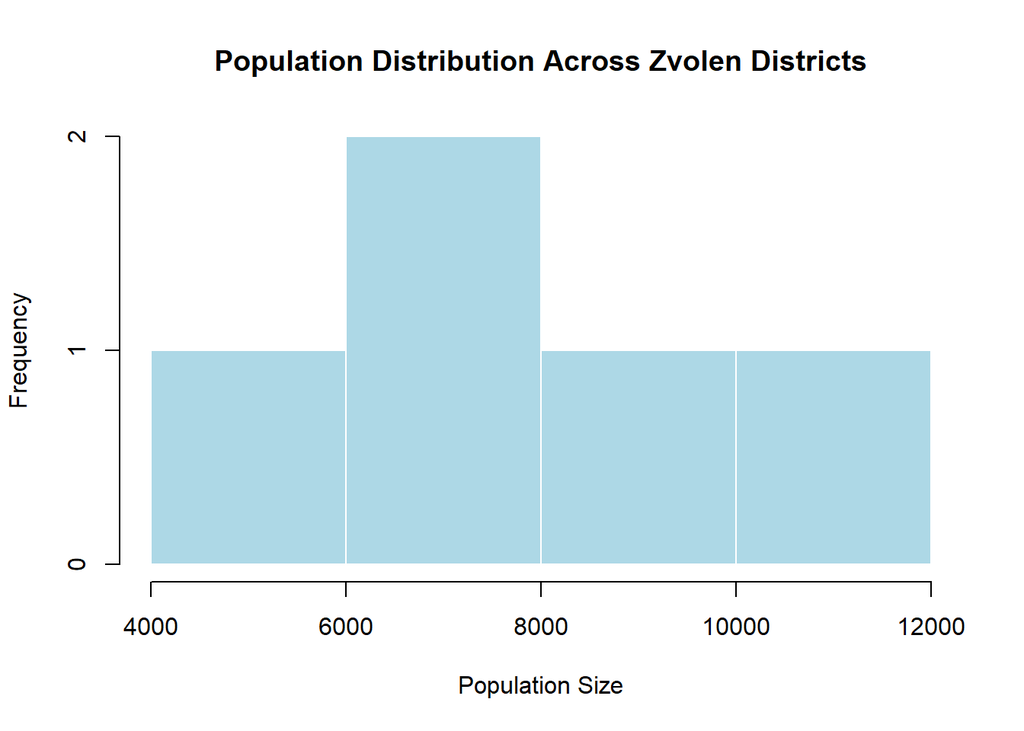

```r
hist(
  zvolen_df$Population_Size,
  main = "Population Distribution Across Zvolen Districts",
  xlab = "Population Size",
  col = "lightblue",
  border = "white"
)
```

### 5.2. The Relationship Map (ggplot2 Scatter Plot)

Now, let’s look for patterns using the industry-standard package, **ggplot2**.

1. Choose **two numeric variables** to see if they are correlated.
2. Create a scatter plot using `geom_point()`.
3. Add `geom_smooth()` to add a relationship between variables to the plot.
4. Add `labs()` to rename your axes and title.

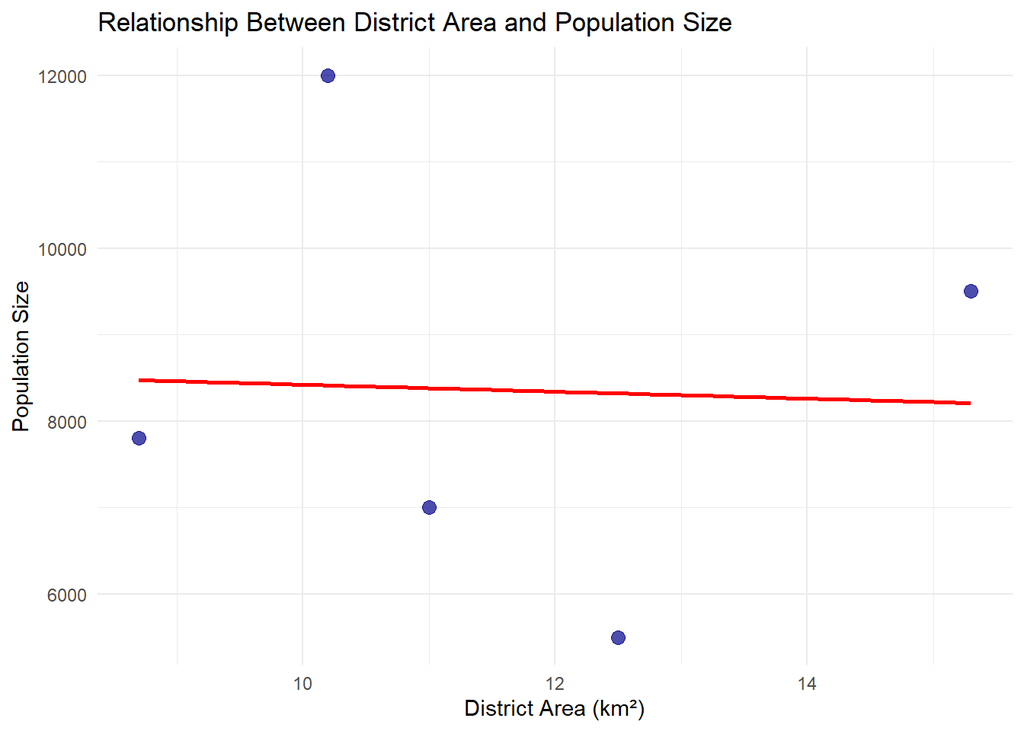

```r
ggplot(zvolen_df, aes(x = Area_km2, y = Population_Size)) +
  geom_point(size = 3, alpha = 0.7, colour = "darkblue") +
  geom_smooth(method = "lm", se = FALSE, color = "red") +
  labs(
    title = "Relationship Between District Area and Population Size",
    x = "District Area (km²)",
    y = "Population Size"
  ) +
  theme_minimal()
```

### 5.3. The Comparison (ggplot2 Boxplot)

3. The Comparison (ggplot2 Boxplot)

Boxplots are excellent for comparing groups. Let’s see how different categories in your universe perform.

1. Choose a **categorical (or logical) variable** for the X-axis (e.g., city, planet_type, species).
2. Choose a **numeric variable** for the Y-axis (e.g., price, gravity, lifespan).
3. Create a plot using `geom_boxplot()`.
4. **Bonus:** Use `fill` to colour the boxes by the same category.

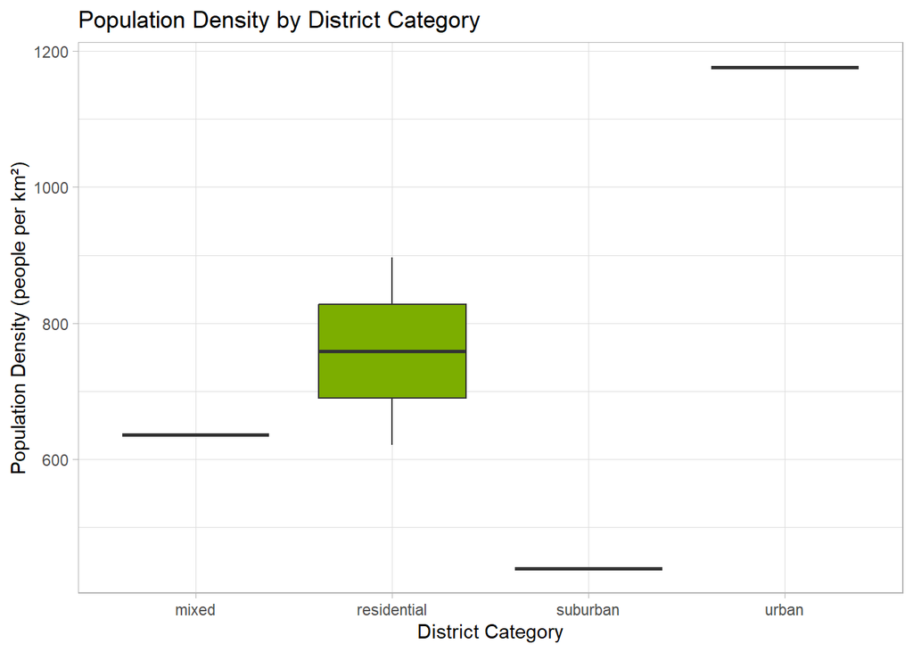

```r
ggplot(zvolen_df, aes(x = Category, y = Density, fill = Category)) +
  geom_boxplot() +
  labs(
    title = "Population Density by District Category",
    x = "District Category",
    y = "Population Density (people per km²)"
  ) +
  theme_light() +
  theme(legend.position = "none")
```

### 5.4. The “Deep Dive” (Faceting or Custom)

The most powerful feature of `ggplot2` is faceting—creating small multiples of the same plot for different groups.

1. Create a plot (histogram, bar plot, or scatter plot).
2. Use `facet_wrap(~ your_category_variable)` to split the plot into a separate panel for each group in your data.
3. This is incredibly useful for comparing distinct groups (e.g., separate charts for each City or Year).

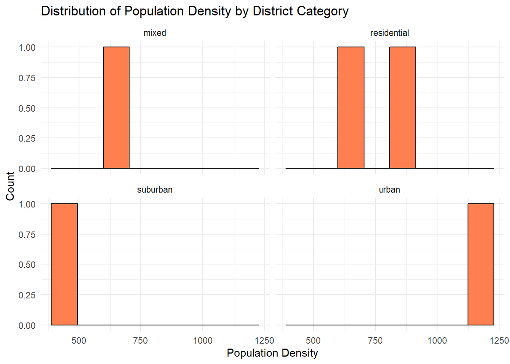

```r
ggplot(zvolen_df, aes(x = Density)) +
  geom_histogram(bins = 8, fill = "coral", color = "black") +
  facet_wrap(~ Category) +
  labs(
    title = "Distribution of Population Density by District Category",
    x = "Population Density",
    y = "Count"
  ) +
  theme_minimal()
```

### 5.5. Final Step: Exporting (Saving Your Work)

A plot is useless if you can’t put it in a report.

1. Choose your favourite plot from the exercises above.
2. Run the code to display it in R.
3. Immediately run the following command to save it to your project folder:

```r
ggsave("zvolen_faceted_histogram.png", width = 8, height = 6)
```